## Peer Grader Guidance

Please review the student expectations for peer review grading and peer review comments. Overall, we ask that you score with accuracy. When grading your peers, you will not only learn how to improve your future homework submissions but you will also gain deeper understanding of the concepts in the assignments. When assigning scores, consider the responses to the questions given your understanding of the problem and using the solutions as a guide. Moreover, please give partial credit for a concerted effort, but also be thorough. **Add comments to your review, particularly when deducting points, to explain why the student missed the points.** Ensure your comments are specific to questions and the student responses in the assignment.

# Background

You have been contracted as a healthcare consulting company to understand the factors on which the pricing of health insurance depends.

## Data Description

The data consists of a data frame with 1338 observations on the following 7 variables:

1. price: Response variable ($)
2. age: Quantitative variable
3. sex: Qualitative variable
4. bmi: Quantitative variable
5. children: Quantitative variable
6. smoker: Qualitative variable
7. region: Qualitative variable

## Instructions on reading the data

To read the data in `R`, save the file in your working directory (make sure you have changed the directory if different from the R working directory) and read the data using the `R` function `read.csv()`

```r
insurance = read.csv("insurance.csv", head = TRUE)
library(ggplot2)
```

# Question 1: Exploratory Data Analysis [15 points]

1. **4 pts** Create scatterplots of the response, *price*, against three quantitative predictors *age*, *bmi*, and *children*. Describe the general trend (direction and form) of each plot. It should be 3 separate scatter plots.

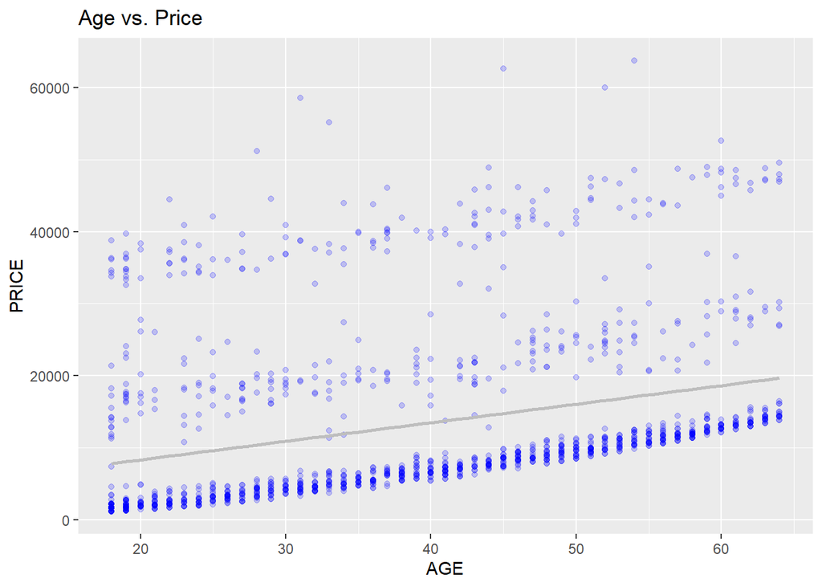

```r
ggplot(data = insurance, aes(x=age, y=price)) +
  geom_point(alpha=I(0.2),color = 'blue')+
  xlab('AGE')+ ylab('PRICE')+ ggtitle('Age vs. Price')+
  geom_smooth(method="lm", color='gray', se=FALSE)
```

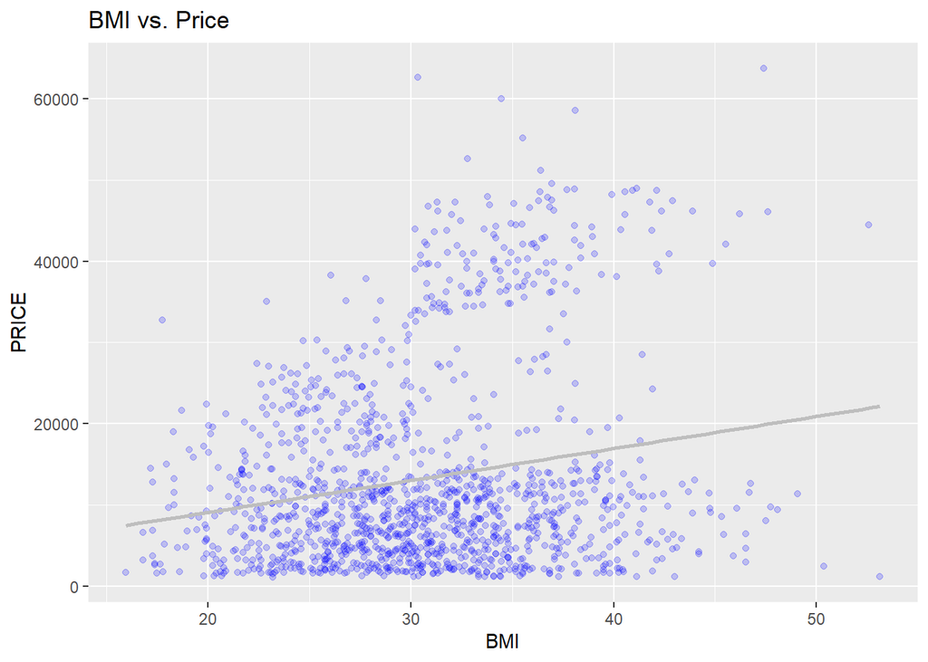

```r
ggplot(data = insurance, aes(x=bmi, y=price)) +
  geom_point(alpha=I(0.2),color = 'blue')+
  xlab('BMI')+ ylab('PRICE')+ ggtitle('BMI vs. Price')+
  geom_smooth(method="lm", color='gray', se=FALSE)
```

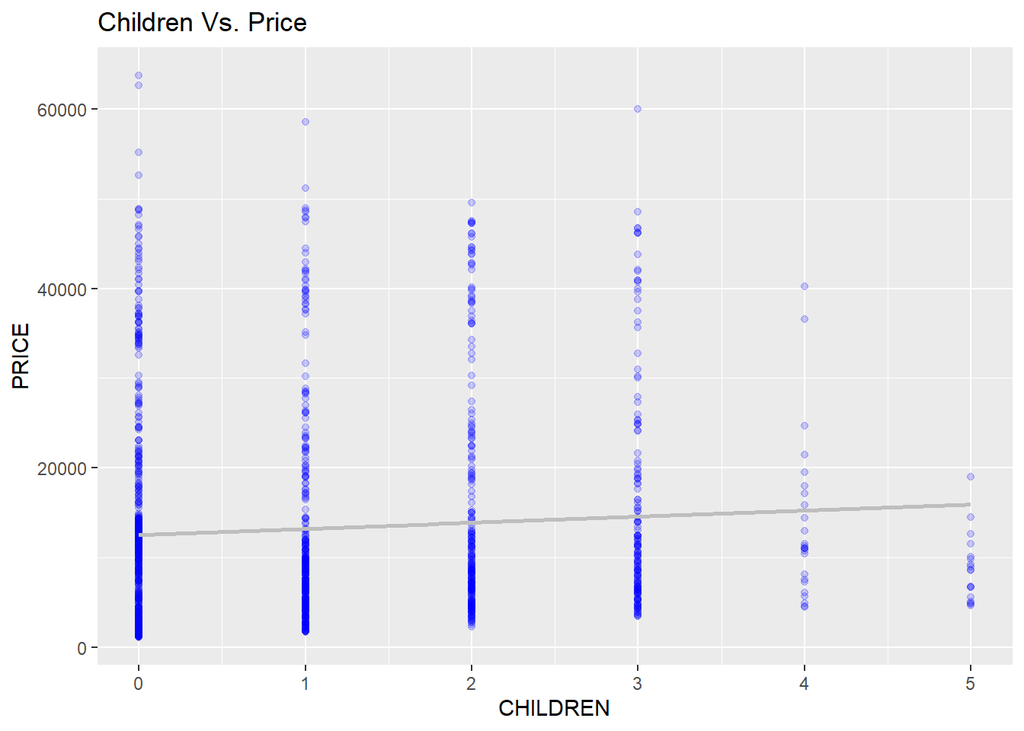

```r
ggplot(data = insurance, aes(x=children, y=price)) +
  geom_point(alpha=I(0.2),color = 'blue')+
  xlab('CHILDREN')+ ylab('PRICE')+ ggtitle('Children Vs. Price')+
  geom_smooth(method="lm", color='gray', se=FALSE)
```

Generally as the age increases, so does the price in a positive linear relationship. However price does vary by age to a degree.

2. **4 pts** What is the value of the correlation coefficient for each of the above pair of response and predictor variables? What does it tell you about your comments in part (a)?

```r
cor(insurance$price,insurance$age)
```

```
## [1] 0.2990082
```

```r
cor(insurance$price, insurance$bmi)
```

```
## [1] 0.198341
```

```r
cor(insurance$price, insurance$children)
```

```
## [1] 0.06799823
```

3. **4 pts** Create box plots of the response, *price*, and the three qualitative predictors *sex*, *smoker*, and *region*. Based on these box plots, does there appear to be a relationship between these qualitative predictors and the response?

*Hint*: Use the given code to convert the qualitative predictors to factors.

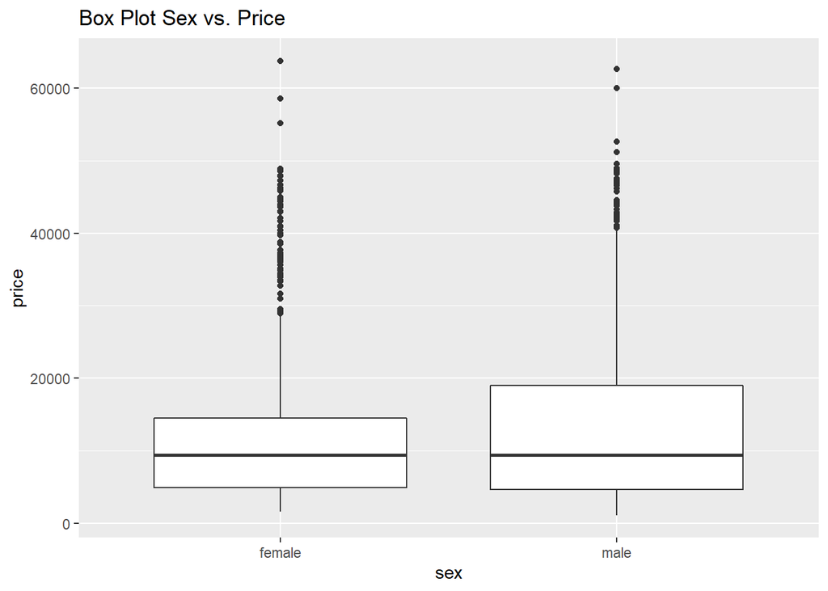

```r
#make categorical variables into factors
insurance$sex<-as.factor(insurance$sex) #makes female the baseline level
insurance$smoker<-as.factor(insurance$smoker) #makes no the baseline level
insurance$region<-as.factor(insurance$region) #makes northeast the baseline level
ggplot(insurance, aes(x=sex, y=price)) +
  geom_boxplot()+ ggtitle("Box Plot Sex vs. Price")
```

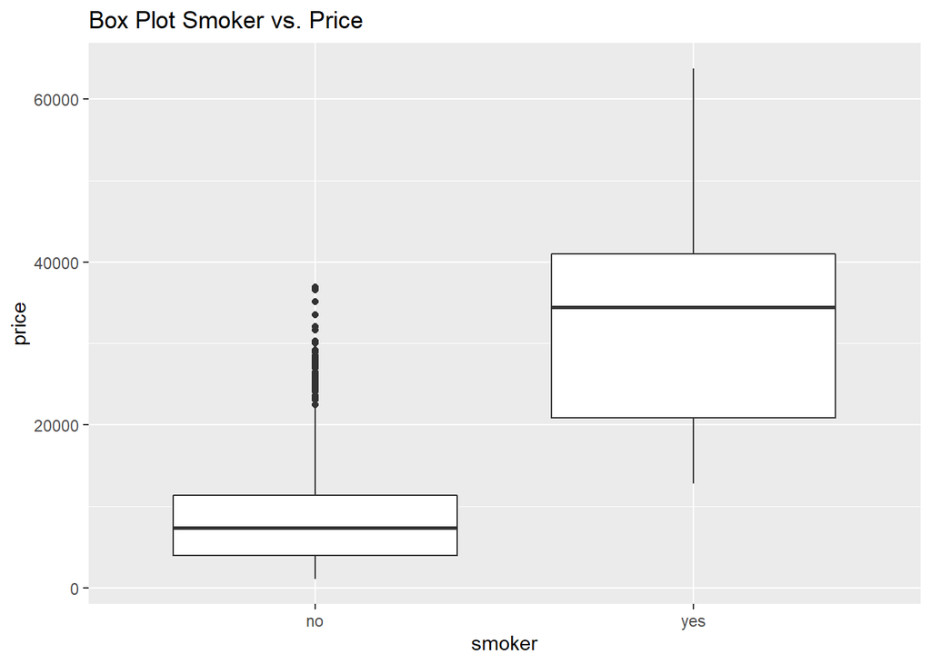

```r
ggplot(insurance, aes(x=smoker, y=price)) +
  geom_boxplot()+ ggtitle("Box Plot Smoker vs. Price")
```

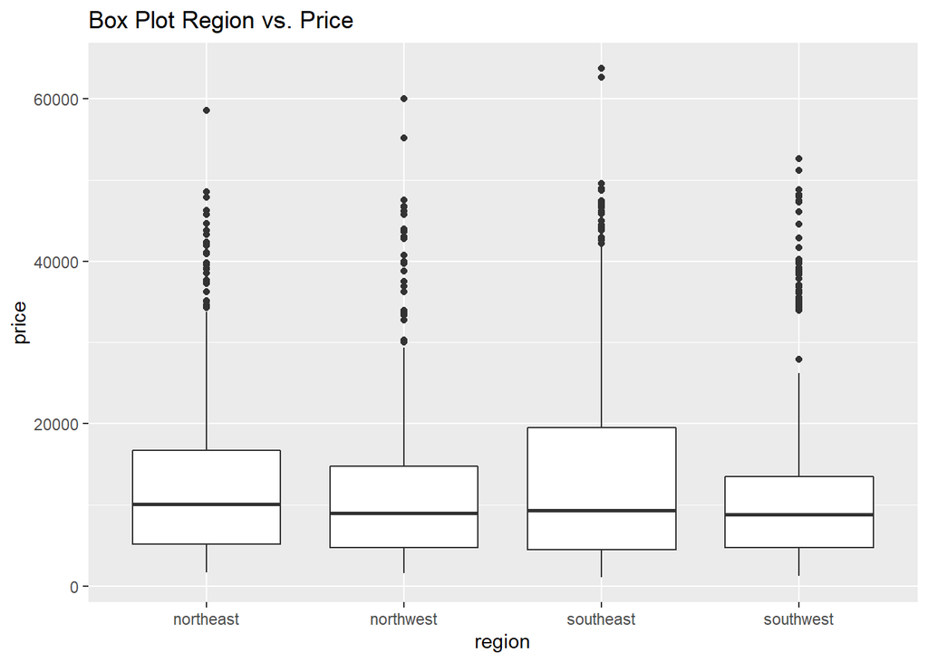

```r
ggplot(insurance, aes(x=region, y=price)) +
  geom_boxplot()+ ggtitle("Box Plot Region vs. Price")
```

Based on the Box-Plots, I would say that there could be a positive linear relationship with smokers and increase in price. And there are differences in price/relationship between gender. Region could pose slight differences as well but I don’t notice anything significant.

4. **3 pts** Based on the analysis above, does it make sense to run a multiple linear regression with all of the predictors?

Yes, I think it makes sense to do a multiple linear regression with all the predictors. No one predictor had a very strong correlation/relationship with price so it would make sense to include them all in the run as a multiple linear regression.Rerunning the model without region to see if it’s a better fit might be helpful.

# Question 2: Fitting the Multiple Linear Regression Model [12 points]

Build a multiple linear regression model, named *model1*, using the response, *price*, and all 6 predictors, and then answer the questions that follow:

1. **6 pts** Report the coefficient of determination (R-squared) for the model and give a concise interpretation of this value.

```r
model1 = lm(price ~.,data = insurance)
summary(model1)
```

```
##
## Call:
## lm(formula = price ~ ., data = insurance)
##
## Residuals:
##      Min       1Q   Median       3Q      Max
## -11304.9  -2848.1   -982.1   1393.9  29992.8
##
## Coefficients:
##                 Estimate Std. Error t value Pr(>|t|)
## (Intercept)     -11938.5      987.8 -12.086  < 2e-16 ***
## age                256.9       11.9  21.587  < 2e-16 ***
## sexmale           -131.3      332.9  -0.394 0.693348
## bmi                339.2       28.6  11.860  < 2e-16 ***
## children           475.5      137.8   3.451 0.000577 ***
## smokeryes        23848.5      413.1  57.723  < 2e-16 ***
## regionnorthwest   -353.0      476.3  -0.741 0.458769
## regionsoutheast  -1035.0      478.7  -2.162 0.030782 *
## regionsouthwest   -960.0      477.9  -2.009 0.044765 *
## ---
## Signif. codes:  0 '***' 0.001 '**' 0.01 '*' 0.05 '.' 0.1 ' ' 1
##
## Residual standard error: 6062 on 1329 degrees of freedom
## Multiple R-squared:  0.7509, Adjusted R-squared:  0.7494
## F-statistic: 500.8 on 8 and 1329 DF,  p-value: < 2.2e-16
```

R-squared is .7509 which means that approximately 75% of the variability of responses is explained by model1. This is not a terrible result, but it could be better.

2. **6 pts** Is the model of any use in predicting price? Using $\alpha = 0.05$, provide the following elements of the test of overall regression of the model: null hypothesis $H_0$, alternative hypothesis $H_a$, $F$-statistic or $p$-value, and conclusion.

The Null Hypothesis would would be that all of the regression coefficients are zero and the alternate hypothesis would be that we reject the null hypothesis because it is not true (and all of the regression coefficients are not zero). Because in this instance the p-value is <2.2e-16 (close to zero) which is smaller than the alpha of .05, we reject the null hypothesis and confirm that this model is helpful in predicting price.

# Question 3: Model Comparison [14 points]

1. **5 pts** Assuming a marginal relationship between *region* and *price*, perform an ANOVA $F$-test on the mean insurance prices among the different regions. Using an $\alpha$-level of 0.05, can we reject the null hypothesis that the means of the regions are equal? Please interpret.

```r
modelanova = aov(price ~ region, insurance)
summary(modelanova)
```

```
##               Df    Sum Sq   Mean Sq F value Pr(>F)
## region         3 1.301e+09 433586560    2.97 0.0309 *
## Residuals   1334 1.948e+11 146007093
## ---
## Signif. codes:  0 '***' 0.001 '**' 0.01 '*' 0.05 '.' 0.1 ' ' 1
```

The p-value of the F-test is .0309, which is less than the alpha level of .05. We can then reject the null hypothesis that the mean price of the regions are all equal, and conclude that at least two means are statistically significantly differ from each other.

2. **5 pts** Now, build a second multiple linear regression model, called *model2*, using *price* as the response variable, and all variables except *region* as the predictors. Conduct a partial $F$-test comparing *model2* with *model1*. What is the partial-F test p-value? Can we reject the null hypothesis that the regression coefficients for *region* variables are zero at an $\alpha$-level of 0.05?

```r
model2 = lm(price ~ age + bmi + children + sex + smoker,data = insurance)
summary(model2)
```

```
##
## Call:
## lm(formula = price ~ age + bmi + children + sex + smoker, data = insurance)
##
## Residuals:
##      Min       1Q   Median       3Q      Max
## -11837.2  -2916.7   -994.2   1375.3  29565.5
##
## Coefficients:
##              Estimate Std. Error t value Pr(>|t|)
## (Intercept) -12052.46     951.26 -12.670  < 2e-16 ***
## age            257.73      11.90  21.651  < 2e-16 ***
## bmi            322.36      27.42  11.757  < 2e-16 ***
## children       474.41     137.86   3.441 0.000597 ***
## sexmale       -128.64     333.36  -0.386 0.699641
## smokeryes    23823.39     412.52  57.750  < 2e-16 ***
## ---
## Signif. codes:  0 '***' 0.001 '**' 0.01 '*' 0.05 '.' 0.1 ' ' 1
##
## Residual standard error: 6070 on 1332 degrees of freedom
## Multiple R-squared:  0.7497, Adjusted R-squared:  0.7488
## F-statistic:   798 on 5 and 1332 DF,  p-value: < 2.2e-16
```

```r
anova(model2, model1)
```

```
## Analysis of Variance Table
##
## Model 1: price ~ age + bmi + children + sex + smoker
## Model 2: price ~ age + sex + bmi + children + smoker + region
##   Res.Df        RSS Df Sum of Sq      F  Pr(>F)
## 1   1332 4.9073e+10
## 2   1329 4.8840e+10  3 233431209 2.1173 0.09622 .
## ---
## Signif. codes:  0 '***' 0.001 '**' 0.01 '*' 0.05 '.' 0.1 ' ' 1
```

Since the F test-statistic from the ANOVA is 2.1173 and the corresponding p-value is .09622 we fail to reject the null hypotheseis that the regression coefficients for region are zero, thus we don’t have sufficient evidence to say that region as a predictor variable is statistically significant (and can remove it from the model)

3. **4 pts** What can you conclude from 3a and 3b? Do they provide the exact same results?

We can conclude that although the means are statistically significantly different between the regions (from an alpha at .05), region as a predictor does not significantly improve the fit of the model. They don’t provide us the same exact results, so it’s partly a judgement call and how strigent we want to be with our alphas.

*Note: Please use model1 for all of the following questions.*

# Question 4: Coefficient Interpretation [7 points]

1. **3 pts** Interpret the estimated coefficient of *sexmale* in the context of the problem. *Make sure female is the baseline level for sex. Mention any assumptions you make about other predictors clearly when stating the interpretation.*

```r
contrasts(insurance$sex)
```

```
##        male
## female    0
## male      1
```

```r
summary(model1)$coef
```

```
##                    Estimate Std. Error     t value     Pr(>|t|)
## (Intercept)     -11938.5386  987.81918 -12.0857530 5.579044e-32
## age                256.8564   11.89885  21.5866552 7.783217e-89
## sexmale           -131.3144  332.94544  -0.3944020 6.933475e-01
## bmi                339.1935   28.59947  11.8601306 6.498194e-31
## children           475.5005  137.80409   3.4505546 5.769682e-04
## smokeryes        23848.5345  413.15335  57.7232020 0.000000e+00
## regionnorthwest   -352.9639  476.27579  -0.7410914 4.587689e-01
## regionsoutheast  -1035.0220  478.69221  -2.1621870 3.078174e-02
## regionsouthwest   -960.0510  477.93302  -2.0087563 4.476493e-02
```

2. **4 pts** If the value of the *bmi* in *model1* is increased by 0.01 and the other predictors are kept constant, what change in the response would be expected?

```r
summary(model1)
```

```
##
## Call:
## lm(formula = price ~ ., data = insurance)
##
## Residuals:
##      Min       1Q   Median       3Q      Max
## -11304.9  -2848.1   -982.1   1393.9  29992.8
##
## Coefficients:
##                 Estimate Std. Error t value Pr(>|t|)
## (Intercept)     -11938.5      987.8 -12.086  < 2e-16 ***
## age                256.9       11.9  21.587  < 2e-16 ***
## sexmale           -131.3      332.9  -0.394 0.693348
## bmi                339.2       28.6  11.860  < 2e-16 ***
## children           475.5      137.8   3.451 0.000577 ***
## smokeryes        23848.5      413.1  57.723  < 2e-16 ***
## regionnorthwest   -353.0      476.3  -0.741 0.458769
## regionsoutheast  -1035.0      478.7  -2.162 0.030782 *
## regionsouthwest   -960.0      477.9  -2.009 0.044765 *
## ---
## Signif. codes:  0 '***' 0.001 '**' 0.01 '*' 0.05 '.' 0.1 ' ' 1
##
## Residual standard error: 6062 on 1329 degrees of freedom
## Multiple R-squared:  0.7509, Adjusted R-squared:  0.7494
## F-statistic: 500.8 on 8 and 1329 DF,  p-value: < 2.2e-16
```

If the value of bmi increases by .01 and the other predictors are kept constant, I would expect the price to increase by 339.2 x .01 = 3.39.

# Question 5: Confidence and Prediction Intervals [12 points]

1. **6 pts** Compute 90% and 95% confidence intervals (CIs) for the parameter associated with *age* for *model1*. What observations can you make about the width of these intervals?

```r
confint(model1, 'age', level = 0.95)
```

```
##        2.5 %   97.5 %
## age 233.5138 280.1989
```

```r
confint(model1, 'age', level = 0.90)
```

```
##          5 %     95 %
## age 237.2708 276.4419
```

2. **3 pts** Using *model1*, estimate the average price for all insurance policies with the same characteristics as the first data point in the sample. What is the 95% confidence interval? Provide an interpretation of your results.

```r
data1 <- insurance[1,]
predict(model1, data1, interval = "prediction", level = 0.95)
```

```
##        fit      lwr      upr
## 1 25293.71 13345.93 37241.49
```

3. **3 pts** Suppose that the *age* value for the first data point is increased to 50, while all other values are kept fixed. Using *model1*, predict the price of an insurance policy with these characteristics. What is the 95% prediction interval? Provide an interpretation of your results.

```r
contrasts(insurance$region)
```

```
##           northwest southeast southwest
## northeast         0         0         0
## northwest         1         0         0
## southeast         0         1         0
## southwest         0         0         1
```

```r
contrasts(insurance$smoker)
```

```
##     yes
## no    0
## yes   1
```